# miRNA.RandomForest

José Javier Herranz Bañón

2023-08-19

```r
library(caret)
library(glmnet)
library(tidyverse)
library(ggplot2)
```

## Establecimiento de la semilla de aleatoriedad:

```r
set.seed(124)
```

# Preprocesado:

### Carga de la matriz balanceada sin reducción de variables y con solo las visitas “Base-Line”.

```r
Final.full.matrix.BL.sub <- readRDS(file = "Final.full.matrix.BL.sub")
```

### Dimensiones de la matriz.

```r
dim(Final.full.matrix.BL.sub)
```

```
## [1]  288 2657
```

### Comprobación de valores nulos:

```r
sum(is.na(Final.full.matrix.BL.sub))
```

```
## [1] 0
```

### Entropía:

$$H(S) = −p⊕ log2 p⊕ − p⊖ log2 p⊖$$
Dado que los datos han sido balanceados, la proporción de valores positivos es igual a la de negativos. Por tanto H(S) = 1.

### Variables y partición de entrenamiento y test:

```r
test <- sample(1:nrow(Final.full.matrix.BL.sub), nrow(Final.full.matrix.BL.sub) * 0.3)
length(test)
```

```
## [1] 86
```

RECORDAMOS: La clase 0 son sanos y la 1 son enfermos de parkinson.

```r
levels(Final.full.matrix.BL.sub[, "Status.1"])
```

```
## [1] "0" "1"
```

```r
levels(Final.full.matrix.BL.sub[, "Status.1"]) <- c("Sano", "Parkinson") # Para que no haya problemas con los nombres de las variables los nombramos.

# Comprobamos que no se ha alterado la proporción de pacientes:
length(as.list(Final.full.matrix.BL.sub[Final.full.matrix.BL.sub$Status.1 == "Sano",1]))
```

```
## [1] 144
```

```r
length(as.list(Final.full.matrix.BL.sub[Final.full.matrix.BL.sub$Status.1 == "Parkinson",1]))
```

```
## [1] 144
```

### Datos de test:

```r
test.data <- Final.full.matrix.BL.sub[,!(names(Final.full.matrix.BL.sub) %in% c("Status.1"))]
test.response <- Final.full.matrix.BL.sub[, "Status.1"]
```

# Modelo de Random-Forest con caret, “Ranger”:

### cálculo de la raiz de las columnas como orientación para el tamaño de los árboles:

```r
sqrt(ncol(Final.full.matrix.BL.sub))
```

```
## [1] 51.5461
```

```r
# 51.5361
```

### trainControl (Validación cruzada de 5 pliegues):

```r
rf.control.cv.5 <- trainControl(method = "cv", number = 5, returnResamp = "final", verboseIter = FALSE)
```

### Grid para hacer tunning:

```r
rf.grid.ranger <- expand.grid(mtry = c(100, 75, 50, 25, 5), splitrule = "gini", min.node.size = c(5, 15, 30, 60, 90))
# Para este modelo se usó ranger.
# Para este modelo se usó la norma de división de impureza de Gini, la fución acepta eso o variance.
# Se establece el tamaño mínimo de nodo para que el arbol no se haga muy grande, probamos varios valores.
```

### Entrenamiento:

#### Ranger:

```r
rf.cv.5.ranger <- train(Status.1 ~ ., data = Final.full.matrix.BL.sub[-test,],
                  method = "ranger",
                  metric = "Accuracy",
                  trControl= rf.control.cv.5,
                  tuneGrid = rf.grid.ranger,
                  num.trees = 500,
                  importance = "impurity")
```

```r
# Guardar el modelo
saveRDS( rf.cv.5.ranger, file = "rf.cv.5.ranger")
```

### Modelo:

```r
rf.cv.5.ranger <- readRDS("./rf.cv.5.ranger")
rf.cv.5.ranger
```

```
## Random Forest
##
##  202 samples
## 2656 predictors
##    2 classes: 'Sano', 'Parkinson'
##
## No pre-processing
## Resampling: Cross-Validated (5 fold)
## Summary of sample sizes: 161, 162, 161, 162, 162
## Resampling results across tuning parameters:
##
##   mtry  min.node.size  Accuracy   Kappa
##     5    5             0.6185366  0.2367564
##     5   15             0.6576829  0.3140469
##     5   30             0.6336585  0.2651384
##     5   60             0.6434146  0.2846881
##     5   90             0.6135366  0.2274532
##    25    5             0.6289024  0.2553706
##    25   15             0.6386585  0.2749288
##    25   30             0.6436585  0.2853434
##    25   60             0.6434146  0.2838209
##    25   90             0.6331707  0.2654870
##    50    5             0.6680488  0.3341133
##    50   15             0.6582927  0.3150177
##    50   30             0.6682927  0.3352024
##    50   60             0.6584146  0.3142762
##    50   90             0.6479268  0.2943796
##    75    5             0.6684146  0.3355940
##    75   15             0.6339024  0.2645476
##    75   30             0.6334146  0.2644779
##    75   60             0.6536585  0.3058121
##    75   90             0.6431707  0.2857001
##   100    5             0.6484146  0.2950482
##   100   15             0.6484146  0.2946051
##   100   30             0.6439024  0.2848343
##   100   60             0.6680488  0.3338424
##   100   90             0.6335366  0.2660304
##
## Tuning parameter 'splitrule' was held constant at a value of gini
## Accuracy was used to select the optimal model using the largest value.
## The final values used for the model were mtry = 75, splitrule = gini
##  and min.node.size = 5.
```

#### Predicción:

```r
ranger.prediction <- predict(rf.cv.5.ranger, test.data, num.trees = 500, )
saveRDS(ranger.prediction, file = "ranger.prediction")
```

#### Matriz de confusión:

```r
ranger.prediction <- readRDS("./ranger.prediction")
confusionMatrix(ranger.prediction, test.response, positive = "Parkinson")
```

```
## Confusion Matrix and Statistics
##
##            Reference
## Prediction  Sano Parkinson
##   Sano       131        22
##   Parkinson   13       122
##
##                Accuracy : 0.8785
##                  95% CI : (0.8351, 0.9139)
##     No Information Rate : 0.5
##     P-Value [Acc > NIR] : <2e-16
##
##                   Kappa : 0.7569
##
##  Mcnemar's Test P-Value : 0.1763
##
##             Sensitivity : 0.8472
##             Specificity : 0.9097
##          Pos Pred Value : 0.9037
##          Neg Pred Value : 0.8562
##              Prevalence : 0.5000
##          Detection Rate : 0.4236
##    Detection Prevalence : 0.4688
##       Balanced Accuracy : 0.8785
##
##        'Positive' Class : Parkinson
##
```

### Variables importantes, por impureza de gini:

#### Variables que tienen 50 o mayor importancia

```r
length(rf.cv.5.ranger$coefnames)
```

```
## [1] 2656
```

```r
impranger <- varImp(rf.cv.5.ranger)
length(impranger$importance[impranger$importance > 50])
```

```
## [1] 26
```

```r
length(impranger$importance$Overall)
```

```
## [1] 2656
```

#### Las 100 más importantes:

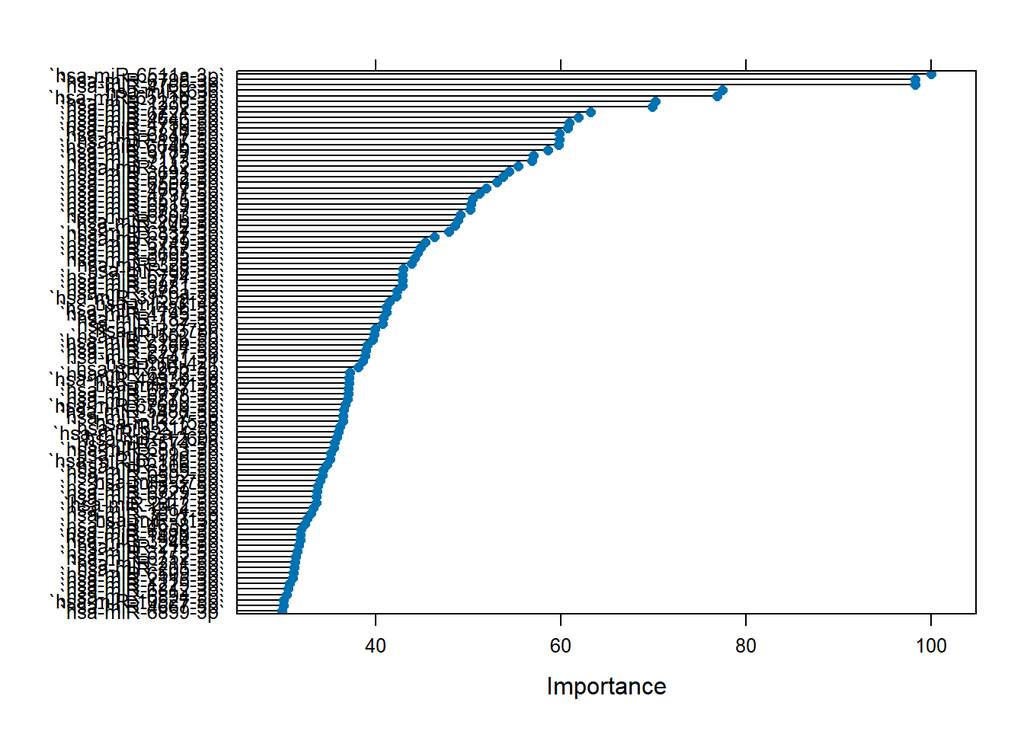

```r
plot(varImp(rf.cv.5.ranger), top=100)
```

*Ordenamos el dataframe por la importancia y sacamos los miRNA de los nombres de fila*

```r
variables <- varImp(rf.cv.5.ranger)
miRNA <- variables$importance
miRNA <- miRNA[order(-miRNA$Overall), , drop = FALSE]
miRNA.list.ordenado <- row.names(miRNA)
```

*Creamos un archivo de texto con los nombres en formato que pide miEAA*

```r
miRNA.ranger <- str_replace_all(miRNA.list.ordenado, "`", "")
miRNAlist.ranger <-file("miRNAlist.ranger.txt")
writeLines(miRNA.ranger[1:100], miRNAlist.ranger)
close(miRNAlist.ranger)
```

# Análisis de enriquecimiento:

## Enriquecimiento por ORA:

En anotaciones significativas se obtuvieron 477 entradas de las cuales 167 estaban relacionadas con Parkinson.

*Resultados de enriquecimiento:*

```r
Results.ranger <- read.csv(file = "./ORA.ranger/miEAA - miRNA Enrichment and Annotation -- ORA results.csv")
Results.ranger
```

```
##                    Category                    Subcategory        Enrichment
## 1 Target genes (miRTarBase)                          PSMB5  over-represented
## 2        Published Diseases Alzheimers Disease deregulated  over-represented
## 3        Published Diseases Alzheimers Disease upregulated  over-represented
## 4 Target genes (miRTarBase)                       ADAMTS13  over-represented
## 5        Published Diseases         melanoma downregulated under-represented
##      P.value P.adjusted   Q.value  Expected Observed
## 1 1.1800e-08  0.0000829 0.0000829  2.936770       16
## 2 2.5300e-04  0.0085150 0.0085150  8.898470       19
## 3 2.8400e-04  0.0085150 0.0085150  5.322050       14
## 4 8.6900e-06  0.0304123 0.0304123  0.347775        5
## 5 2.5512e-03  0.0382682 0.0382682 10.431200        3
##                                                                                                                                                                                                                                                                                                       miR…
## 1                                              hsa-miR-636; hsa-miR-7113-3p; hsa-miR-142-3p; hsa-miR-4667-3p; hsa-miR-6819-3p; hsa-miR-6749-3p; hsa-miR-3605-3p; hsa-miR-6741-3p; hsa-miR-6778-3p; hsa-miR-6769b-3p; hsa-miR-30e-5p; hsa-miR-6817-3p; hsa-miR-1914-5p; hsa-miR-215-5p; hsa-miR-6752-3p; h…
## 2 hsa-miR-371b-5p; hsa-miR-6803-3p; hsa-miR-6837-3p; hsa-miR-937-3p; hsa-miR-3157-3p; hsa-miR-3605-3p; hsa-miR-328-3p; hsa-miR-3150a-5p; hsa-miR-3143; hsa-miR-148b-3p; hsa-miR-421; hsa-miR-26b-3p; hsa-miR-548d-5p; hsa-miR-1260a; hsa-miR-6817-3p; hsa-miR-148b-5p; hsa-miR-215-5p; hsa-miR-3173-5p; h…
## 3                                                                                  hsa-miR-371b-5p; hsa-miR-6837-3p; hsa-miR-937-3p; hsa-miR-3157-3p; hsa-miR-3605-3p; hsa-miR-328-3p; hsa-miR-3150a-5p; hsa-miR-421; hsa-miR-26b-3p; hsa-miR-1260a; hsa-miR-6817-3p; hsa-miR-148b-5p; hsa-miR-3173-5p; h…
## 4                                                                                                                                                                                                                                    hsa-miR-6511a-3p; hsa-miR-6511b-3p; hsa-miR-6749-3p; hsa-miR-4745-3p…
## 5                                                                                                                                                                                                                                                                        hsa-miR-1538; hsa-miR-24-2-5p; h…
```

*Anotaciones relevantes:*

```r
Annotations.general.ranger <- read.csv(file = "./ORA.ranger/miEAA - miRNA Enrichment and Annotation -- General annotations.csv")
Annotations.general.ranger[,-4]
```

```
##      MiRNA.precursor                  Category Number.significant.subcategories
## 1    hsa-miR-1227-3p        Published Diseases                               14
## 2    hsa-miR-1227-3p           Diseases (MNDR)                               27
## 3    hsa-miR-1227-3p   Gene Ontology (miRWalk)                              124
## 4    hsa-miR-1227-3p           Pathways (KEGG)                              195
## 5    hsa-miR-1227-3p Target genes (miRTarBase)                              211
## 6    hsa-miR-1227-3p              total number                              571
## 7    hsa-miR-1229-3p        Published Diseases                                4
## 8    hsa-miR-1229-3p           Diseases (MNDR)                               38
## 9    hsa-miR-1229-3p           Pathways (KEGG)                              174
## 10   hsa-miR-1229-3p Target genes (miRTarBase)                              207
## 11   hsa-miR-1229-3p   Gene Ontology (miRWalk)                              837
## 12   hsa-miR-1229-3p              total number                            1,260
## 13   hsa-miR-1238-3p        Published Diseases                                8
## 14   hsa-miR-1238-3p           Diseases (MNDR)                               45
```

[output cut: 463 more lines]

*Anotaciones relevantes con el filtro de Parkinson:*

```r
Annotations.parkinson.ranger <- read.csv(file = "./ORA.ranger/miEAA - miRNA Enrichment and Annotation -- Annotations parkinson.csv")
Annotations.parkinson.ranger[,-4]
```

```
##      MiRNA.precursor        Category Number.significant.subcategories
## 1    hsa-miR-1227-3p Diseases (MNDR)                               27
## 2    hsa-miR-1227-3p Pathways (KEGG)                              195
## 3    hsa-miR-1229-3p Diseases (MNDR)                               38
## 4    hsa-miR-1229-3p Pathways (KEGG)                              174
## 5    hsa-miR-1238-3p Diseases (MNDR)                               45
## 6    hsa-miR-1238-3p Pathways (KEGG)                              106
## 7      hsa-miR-1260a Diseases (MNDR)                               52
## 8      hsa-miR-1260a Pathways (KEGG)                              172
## 9    hsa-miR-1292-3p Diseases (MNDR)                                8
## 10   hsa-miR-1292-3p Pathways (KEGG)                              150
## 11    hsa-miR-142-3p Pathways (KEGG)                              262
## 12    hsa-miR-142-3p Diseases (MNDR)                              389
## 13    hsa-miR-142-5p Pathways (KEGG)                              231
## 14    hsa-miR-142-5p Diseases (MNDR)                              385
```

[output cut: 153 more lines]

# Conclusión:

En este Rmarkdown se ha probado a realizar un modelo con el método para random forest de caret de “ranger”, para ello se ha usado la matriz de miRNA sin reducir y balanceada a 144 enfermos y controles.

Respecto a el modelo hecho con lasso se escogen diferentes miRNAs. El p-valor de Acc > NIR es mucho menor y su precisión balanceada es mayor, kappa también. En general el modelo parece mas efectivo en la clasificación. El modelo final usó mtry 75, como regla de división impureza de gini y un tamaño mínimo de nodo de 5.

El análsis de enriquecimiento ORA no muestra resultados de sobrerrepresentación o infrarrepresentación sobre el parkinson, solo aparece en anotaciones relevantes.Lo que siginifica que los genes usados no están en anotaciones relacionadas con el parkinson, podría se que no tienen que ver o bién que aún no se han identificado como parte de los mecanismos relacionados con la enfermedad.